# 离散型随机变量的概率分布

Author

Simonzhou

Published

February 23, 2025

# 1 离散型随机变量的概率分布

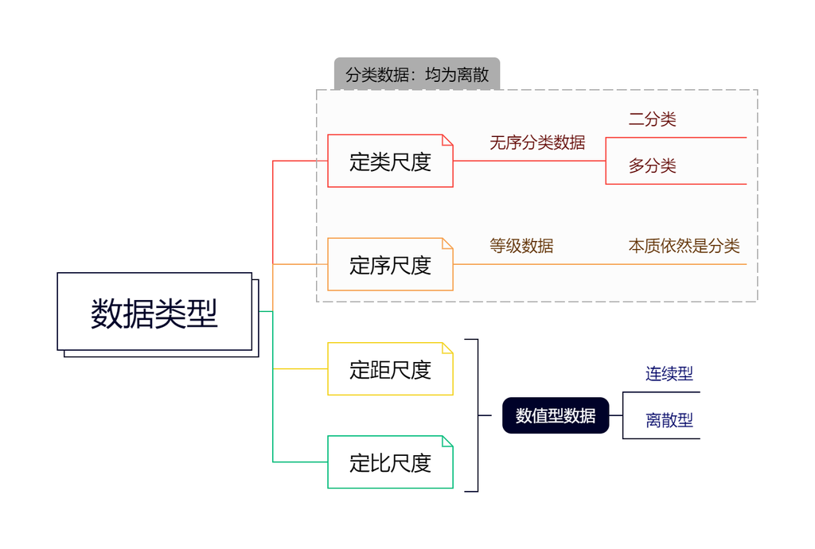

type of data

## 1.1 二项分布(Binomial Distribution)

**定义：**$n$次伯努利试验，成功的次数为$X$的离散概率分布，其中每次试验的成功概率为$\pi$，失败的概率为$1-\pi$。

- $X$的总体均数$\mu_{x}=n\pi$
- 总体方差$\sigma_{x}=n\pi(1-\pi)$

*notice：*

- 实际上，当$n=1$时，二项分布就是伯努利试验。
- 伯努利试验要求：互斥、独立、重复

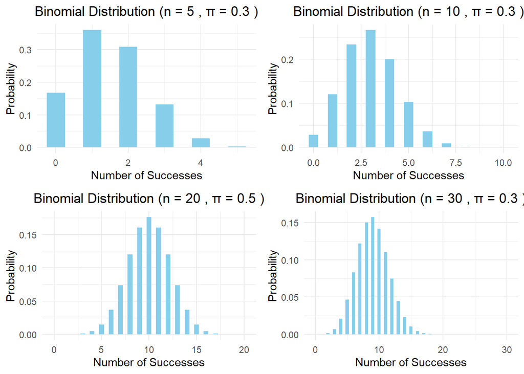

Binomial Distribution with Different n/π

## 1.2 泊松分布(Poission Distribution)

**定义：**描述在单位面积、单位时间或单位空间中罕见事件发生次数的概率分布为泊松分布，记作$P(\mu)$。泊松分布是二项分布的极限形式，当一个二项分布的$n$很大，$\pi$很小时，此时，这个二项分布近似于泊松分布。

- 其总体均数与总体方差相等，记为$\mu$
- 可加性：$X\sim P(\mu_{1})$，$Y\sim P(\mu_{2})$，若$X$与$Y$ 独立，则$X+Y \sim P(\mu_{1}+\mu_{1})$
- 泊松分布只有一个参数$\lambda(\mu)$
- 服从泊松分布的随机变量，其取值为$0$到$+\infty$的概率之和为1
- 一般来说，当$\mu \ge20$时，可以认为近似正态分布

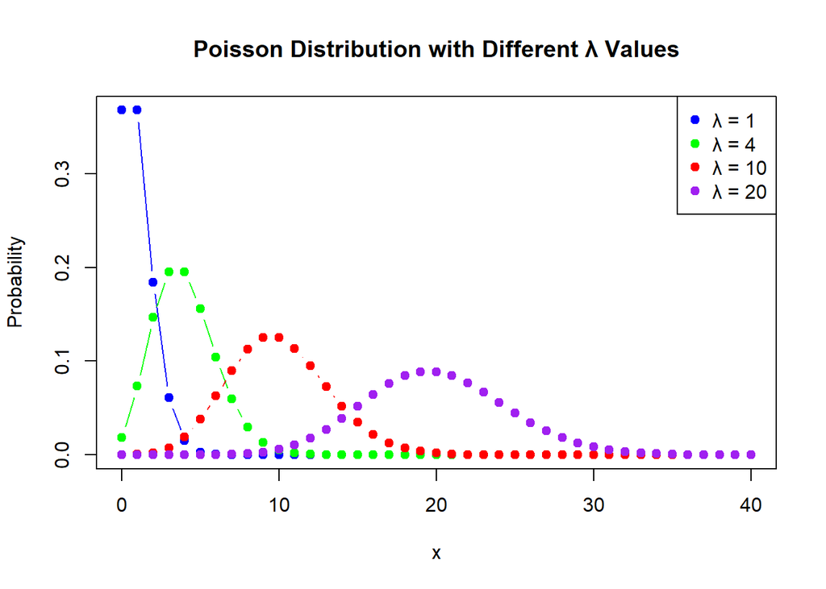

```r
library(ggplot2)
# Define the range for x
x <- 0:40

# Define the lambda values
lambdas <- c(1, 4, 10, 20)

# Set up the plot area
plot(x, dpois(x, lambdas[1]), type="n", ylim=c(0, max(dpois(x, lambdas))),
     xlab="x", ylab="Probability", main="Poisson Distribution with Different λ Values")

# Plot the Poisson distributions for each lambda
colors <- c("blue", "green", "red", "purple")
for (i in 1:length(lambdas)) {
  lines(x, dpois(x, lambdas[i]), type="b", pch=19, col=colors[i])
}

# Add a legend
legend("topright", legend=paste("λ =", lambdas), col=colors, pch=19)
```

[figure not shown]

Poisson Distribution with Different λ=nπ